# Steps to externally validate a prediction model

2019-01-01

## Original prediction model

We will externally validate the following prediction model:

```r
library(foreign)
dat.orig <- read.spss(file="Hipstudy.sav", to.data.frame=T)
```

```
## re-encoding from UTF-8
```

```r
library(rms)
dd <- datadist(dat.orig)
options(datadist='dd')

dat.orig$Mobility <- factor(dat.orig$Mobility)
fit.orig <- lrm(Mortality ~ Gender + Mobility + Age + ASA, x = T, y = T, data = dat.orig)
fit.orig
```

```
## Logistic Regression Model
##
##  lrm(formula = Mortality ~ Gender + Mobility + Age + ASA, data = dat.orig,
##      x = T, y = T)
##
##                        Model Likelihood     Discrimination    Rank Discrim.
##                           Ratio Test           Indexes           Indexes
##  Obs           426    LR chi2      70.28    R2       0.234    C       0.774
##   0            333    d.f.             5    g        1.406    Dxy     0.548
##   1             93    Pr(> chi2) <0.0001    gr       4.080    gamma   0.550
##  max |deriv| 1e-06                          gp       0.184    tau-a   0.187
##                                             Brier    0.145
##
##             Coef    S.E.   Wald Z Pr(>|Z|)
##  Intercept  -9.2172 1.6059 -5.74  <0.0001
##  Gender      0.4623 0.2968  1.56  0.1194
##  Mobility=2  0.4999 0.3014  1.66  0.0971
##  Mobility=3  1.8148 0.5723  3.17  0.0015
##  Age         0.0711 0.0189  3.75  0.0002
##  ASA         0.7219 0.2144  3.37  0.0008
##
```

```r
pred.orig <- predict(fit.orig, type="fitted")
```

### ROC curve and AUC

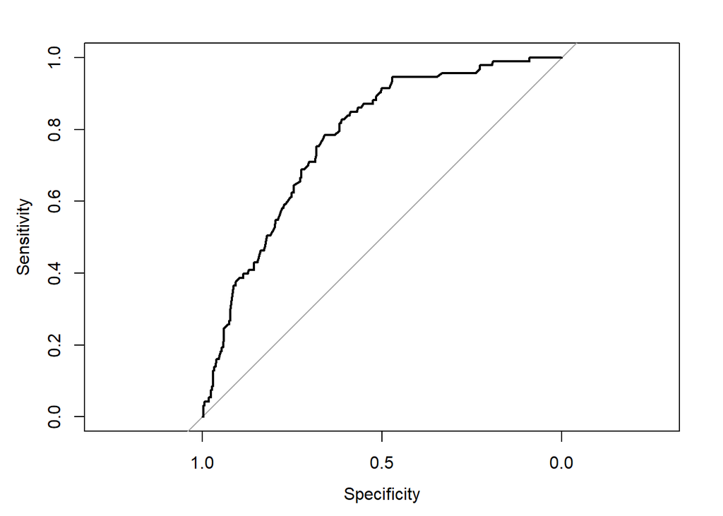

```
##
## Call:
## roc.default(response = fit.orig$y, predictor = pred.orig, ci = TRUE,     plot = TRUE)
##
## Data: pred.orig in 333 controls (fit.orig$y 0) < 93 cases (fit.orig$y 1).
## Area under the curve: 0.7738
## 95% CI: 0.7244-0.8232 (DeLong)
```

```r
library(pROC)
roc(fit.orig$y, pred.orig, ci=TRUE, plot = TRUE)
```

### Calibration curve and H&L test

```r
group.cut <- quantile(pred.orig, c(seq(0, 1, 0.1)))
group <- cut(pred.orig, group.cut)
pred.prob <- tapply(pred.orig, group, mean)

# Observed probabilities
obs.prob <- tapply(fit.orig$y, group, mean)
cal.m <- data.frame(cbind(pred.prob, obs.prob))
```

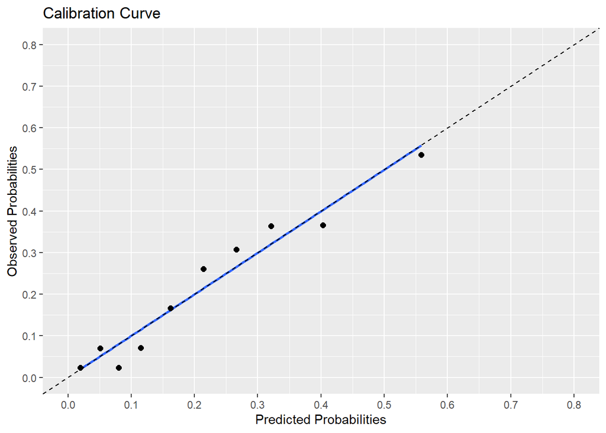

```r
library(ggplot2)
plot(ggplot(cal.m,aes(x=pred.prob,y=obs.prob)) +
  scale_x_continuous(name = "Predicted Probabilities",
    breaks = seq(0, 1, 0.1), limits=c(0, 0.8)) +
  scale_y_continuous(name = "Observed Probabilities",
    breaks = seq(0, 1, 0.1), limits=c(0, 0.8)) +
  geom_smooth(method='lm', formula = y~x, se = FALSE) +
  geom_point(size=2, shape = 19) +
  geom_abline(intercept = 0, slope = 1, linetype=2) +
  ggtitle("Calibration Curve") )
```

```r
library(ResourceSelection)
hoslem.test(fit.orig$y, pred.orig) # Hosmer and Lemeshow test from package ResourceSelection
```

```
##
##  Hosmer and Lemeshow goodness of fit (GOF) test
##
## data:  fit.orig$y, pred.orig
## X-squared = 4.6762, df = 8, p-value = 0.7916
```

This model has an **C-index (ROC) value of 0.774** and an **R2 of 0.234**. **The Hosmer and Lemeshow test is not significant** indicating that the model calibrates well.

## Steps to externally validate a prediction model

#### 1. Determine the Linear Predictor of the model. This is in our case:

```r
coef.orig <- coef(fit.orig)
coef.orig # Coefficients of original model
```

```
##   Intercept      Gender  Mobility=2  Mobility=3         Age         ASA
## -9.21721717  0.46226952  0.49991610  1.81481732  0.07109868  0.72188861
```

#### 2. Transport the original regression coefficients to the external dataset and calculate the linear predictor.

```r
fit.ext <- lrm(Mortality ~ Gender + Mobility + Age + ASA, x = T, y = T, data = dat.ext)
lp.ext <- model.matrix(fit.ext) %*% coef.orig # model.matrix extracts predictor values of external dataset, including dummy coded variables.
```

#### 3. Determine the amount of miscalibration in intercept and calibration slope.

```r
fit.ext.lp <- lrm(fit.ext$y ~ lp.ext)
fit.ext.lp
```

```
## Logistic Regression Model
##
##  lrm(formula = fit.ext$y ~ lp.ext)
##
##                        Model Likelihood     Discrimination    Rank Discrim.
##                           Ratio Test           Indexes           Indexes
##  Obs           300    LR chi2      43.89    R2       0.205    C       0.750
##   0            230    d.f.             1    g        1.271    Dxy     0.499
##   1             70    Pr(> chi2) <0.0001    gr       3.564    gamma   0.501
##  max |deriv| 2e-10                          gp       0.178    tau-a   0.179
##                                             Brier    0.156
##
##            Coef    S.E.   Wald Z Pr(>|Z|)
##  Intercept -0.6594 0.1567 -4.21  <0.0001
##  lp.ext     0.8767 0.1554  5.64  <0.0001
##
```

#### 4. Deterimne Discrimination and Calibration in the external dataset

#### Discrimination

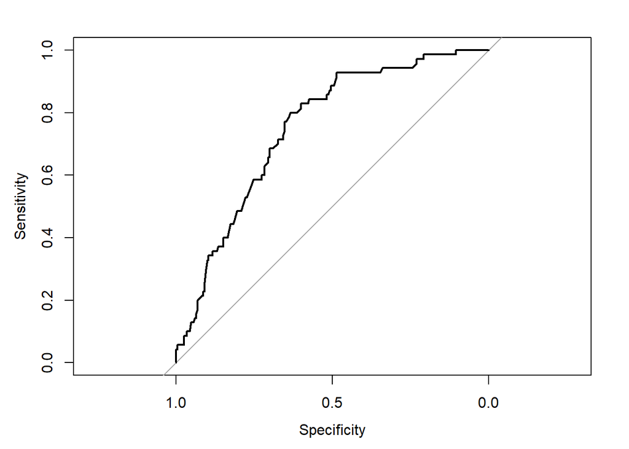

```
##
## Call:
## roc.default(response = fit.ext$y, predictor = pred.ext, ci = TRUE,     plot = TRUE)
##
## Data: pred.ext in 230 controls (fit.ext$y 0) < 70 cases (fit.ext$y 1).
## Area under the curve: 0.7496
## 95% CI: 0.6893-0.8098 (DeLong)
```

```r
pred.ext <-  1/(1+exp(-lp.ext))
roc(fit.ext$y, pred.ext, ci=TRUE, plot = TRUE)
```

#### Calibration

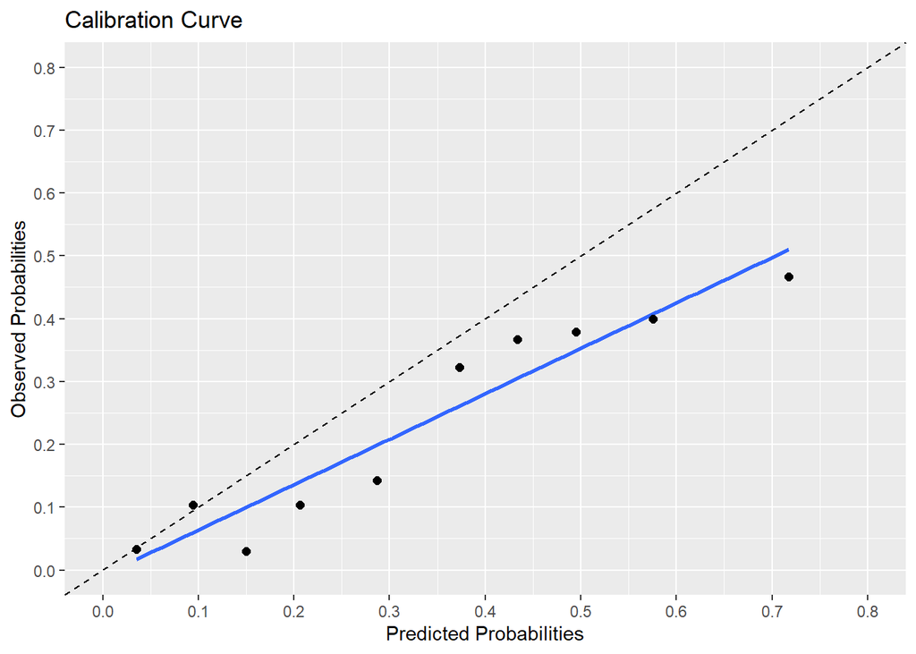

```r
library(ggplot2)
plot(ggplot(cal.m.ext,aes(x=pred.prob,y=obs.prob)) +
  scale_x_continuous(name = "Predicted Probabilities",
    breaks = seq(0, 1, 0.1), limits=c(0, 0.8)) +
  scale_y_continuous(name = "Observed Probabilities",
    breaks = seq(0, 1, 0.1), limits=c(0, 0.8)) +
  geom_smooth(method="lm", formula = y~x, se = FALSE) +
  geom_point(size=2, shape = 19) +
  geom_abline(intercept = 0, slope = 1, linetype=2) +
  ggtitle("Calibration Curve") )
```

The calibration curve deviates from the ideal line.

#### Hosmer and Lemeshow test

```r
hoslem.test(fit.ext$y, pred.ext)
```

```
##
##  Hosmer and Lemeshow goodness of fit (GOF) test
##
## data:  fit.ext$y, pred.ext
## X-squared = 23.991, df = 8, p-value = 0.0023
```

The Hosmer and Lemeshow test is now significant. The test confirms the miscalibration in the intercept and calibration slope, visualized on the calibration curve.

### Incorrect external validation: recalibrated predictions

When you externally validate a prediction model you have to use  
*uncalibrated* predictions. Otherwise the external validation procedure is incorrect.

The uncalibrated predictions were used above and were calculated “outside” the model by using the formula to calculated predicted probabilities:

```r
pred.ext <-  1/(1+exp(-lp.ext))
```

Calibrated predictions are calculated via the prediction model, using:

```r
fit.ext.lp <- lrm(fit.ext$y ~ lp.ext) # the coefficient values reflect the amount of miscalibration
pred.ext.recal <- predict(fit.ext.lp, type="fitted")
```

#### Discrimination

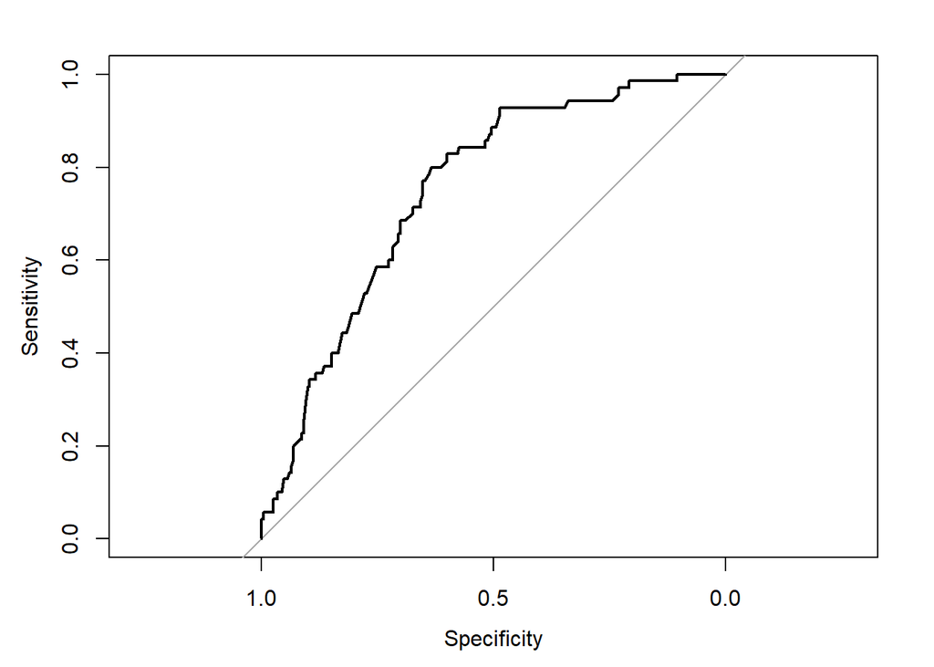

```
##
## Call:
## roc.default(response = fit.ext$y, predictor = pred.ext.recal,     ci = TRUE, plot = TRUE)
##
## Data: pred.ext.recal in 230 controls (fit.ext$y 0) < 70 cases (fit.ext$y 1).
## Area under the curve: 0.7496
## 95% CI: 0.6893-0.8098 (DeLong)
```

```r
roc(fit.ext$y, pred.ext.recal, ci=TRUE, plot = TRUE)
```

#### Calibration

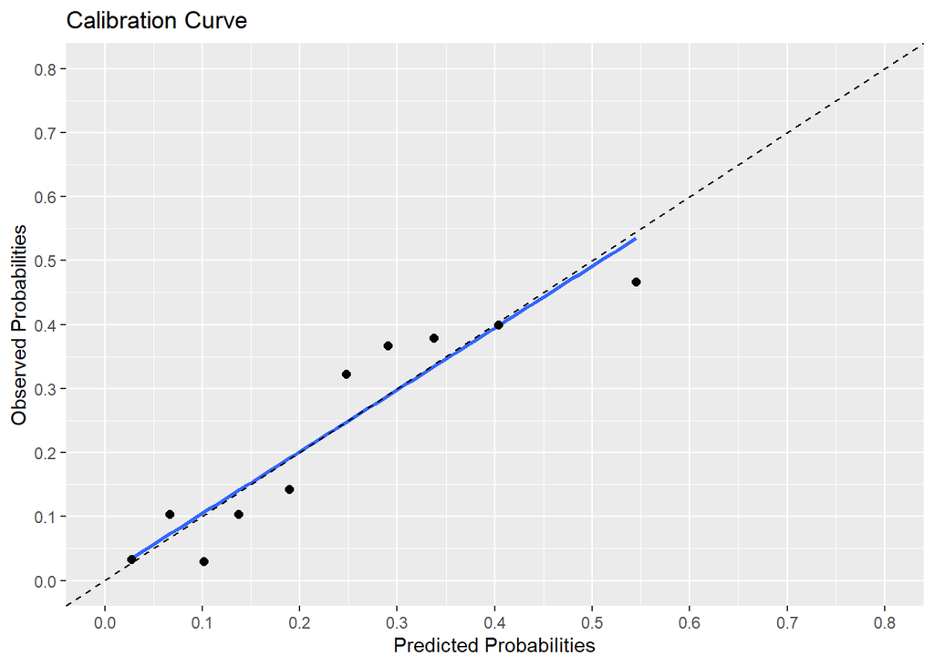

```r
library(ggplot2)
cal.plot <- ggplot(cal.m.ext,aes(x=pred.prob,y=obs.prob)) +
  scale_x_continuous(name = "Predicted Probabilities",
    breaks = seq(0, 1, 0.1), limits=c(0, 0.8)) +
  scale_y_continuous(name = "Observed Probabilities",
    breaks = seq(0, 1, 0.1), limits=c(0, 0.8)) +
  geom_smooth(method="lm", formula = y~x, se = FALSE) +
  geom_point(size=2, shape = 19) +
  geom_abline(intercept = 0, slope = 1, linetype=2) +
  ggtitle("Calibration Curve")
plot(cal.plot)
```

#### Hosmer and Lemeshow test

```r
hoslem.test(fit.ext$y, pred.ext.recal)
```

```
##
##  Hosmer and Lemeshow goodness of fit (GOF) test
##
## data:  fit.ext$y, pred.ext.recal
## X-squared = 5.9383, df = 8, p-value = 0.6541
```

The Hosmer and Lemeshow test is not significant and the calibration curve looks as if the model calibrates well in the external dataset. This is incorrect and the result of working with calibrated predictions. These calibrated predictions do not influence the ROC curve and AUC.

#### For external validation in Multiple Imputed datasets see http://missingdatasolutions.rbind.io/psfmi/.